# Week 05 - Breakout Activity

Sam Stewart

2021-03-19

# 1 Introduction

In week 4 we were presented with 4 questions (dropped the 5th for time):

1. Is there a difference in glucose levels between smokers and non-smokers?
2. Is the difference still present after controlling for sex?
3. Is there an interaction between smoking and sex?
4. Is there an effect of smoking on *hypertension*?

*NOTE: I changed diabetes for hypertension from last week - I always forget how much lower the diabetes rate was in the 80s: https://www.cdc.gov/diabetes/statistics/slides/long_term_trends.pdf.*

I’ll split these into two sections, and explore the answers

# 2 Glucose and Smoking

The primary question is if there is a difference in glucose between smokers and non-smokers. We’ll start with a tabular and graphical summary of the relationship.

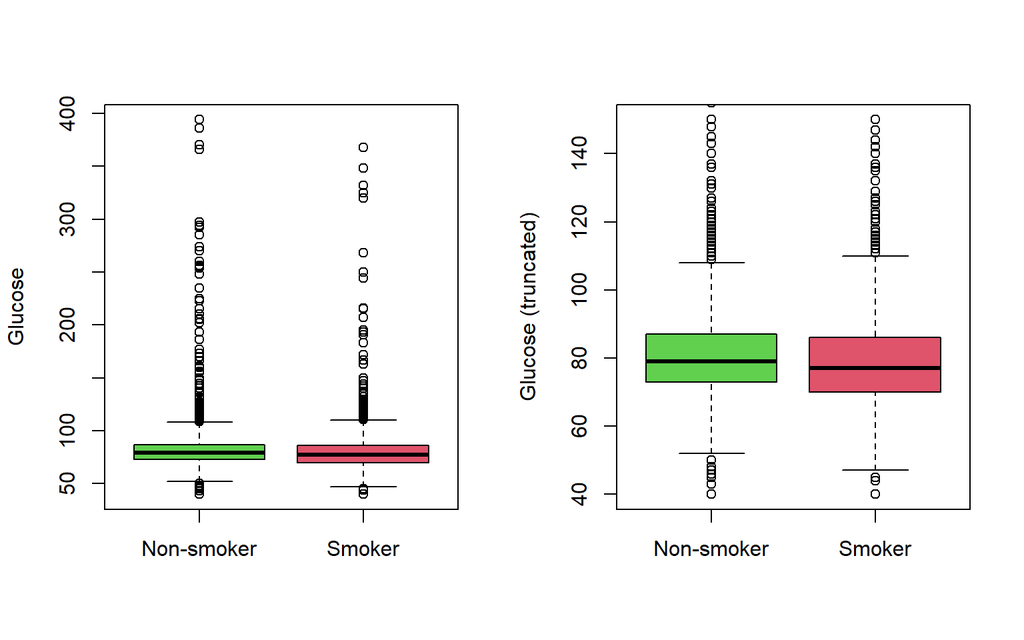

The boxplots show a minimal difference and perhaps some skewness, let’s look at a tabular summary.

Glucose summarized across smoking status (manually, using describe)

|  | n | mean | sd | min | Q0.25 | median | Q0.75 | max |
| --- | --- | --- | --- | --- | --- | --- | --- | --- |
| ALL | 4037 | 82.19 | 24.40 | 40 | 72 | 78 | 87 | 394 |
| Smoker | 1973 | 80.72 | 21.69 | 40 | 70 | 77 | 86 | 368 |
| Non-smoker | 2064 | 83.59 | 26.66 | 40 | 73 | 79 | 87 | 394 |

Glucose levels, overall and stratified by smoking status (automatically, using table1)

|  | Non-smoker (N=2253) | Smoker (N=2181) | Overall (N=4434) |
| --- | --- | --- | --- |
| GLUCOSE |  |  |  |
| Mean (SD) | 83.6 (26.7) | 80.7 (21.7) | 82.2 (24.4) |
| Median [Min, Max] | 79.0 [40.0, 394] | 77.0 [40.0, 368] | 78.0 [40.0, 394] |
| Missing | 189 (8.4%) | 208 (9.5%) | 397 (9.0%) |

```
##
##  Welch Two Sample t-test
##
## data:  GLUCOSE by CURSMOKE
## t = 3.7597, df = 3935.5, p-value = 0.0001726
## alternative hypothesis: true difference in means is not equal to 0
## 95 percent confidence interval:
##  1.373589 4.367345
## sample estimates:
## mean in group Non-smoker     mean in group Smoker
##                 83.58866                 80.71820
```

|  | x |
| --- | --- |
| Non-smoker | 83.5886628 |
| Smoker | 80.7181956 |
| Diff | -2.8704671 |
| LCL | 1.3735892 |
| UCL | 4.3673451 |
| P-value | 0.0001726 |

The difference looks statistically significant, though whether it is clinically meaningful is a different discussion.

**OBJECTIVE 1** Summarize the t-test in a meaningful way, either with a table or in-line.

## 2.1 Investigating relationship to SEX

We want to investigate the effect of sex on this relationship, first as a controlling factor and second as an effect modifier.

The table below presents the stratified effects, and probably suggests a lack of effect modification, but we’ll pursue both models regardless.

Glucose levels, stratified by Sex and Smoking Status

|  | Male Non-smoker (N=769) | Male Smoker (N=1175) | Female Non-smoker (N=1484) | Female Smoker (N=1006) | Overall Non-smoker (N=2253) | Overall Smoker (N=2181) |
| --- | --- | --- | --- | --- | --- | --- |
| GLUCOSE |  |  |  |  |  |  |
| Mean (SD) | 84.5 (28.9) | 80.9 (21.4) | 83.1 (25.3) | 80.5 (22.1) | 83.6 (26.7) | 80.7 (21.7) |
| Median [Min, Max] | 79.0 [43.0, 394] | 77.0 [40.0, 332] | 79.0 [40.0, 394] | 77.0 [45.0, 368] | 79.0 [40.0, 394] | 77.0 [40.0, 368] |
| Missing | 43 (5.6%) | 77 (6.6%) | 146 (9.8%) | 131 (13.0%) | 189 (8.4%) | 208 (9.5%) |

For the regression models we’ll build three - one with smoking, one with smoking and sex, one with their interaction also included.

```
##
## Call:
## lm(formula = GLUCOSE ~ CURSMOKE, data = dat)
##
## Residuals:
##     Min      1Q  Median      3Q     Max
## -43.589 -10.589  -3.718   4.282 310.411
##
## Coefficients:
##                Estimate Std. Error t value Pr(>|t|)
## (Intercept)     83.5887     0.5362 155.890  < 2e-16 ***
## CURSMOKESmoker  -2.8705     0.7670  -3.742 0.000185 ***
## ---
## Signif. codes:  0 '***' 0.001 '**' 0.01 '*' 0.05 '.' 0.1 ' ' 1
##
## Residual standard error: 24.36 on 4035 degrees of freedom
##   (397 observations deleted due to missingness)
## Multiple R-squared:  0.003459,   Adjusted R-squared:  0.003212
## F-statistic: 14.01 on 1 and 4035 DF,  p-value: 0.0001848
```

```
##
## Call:
## lm(formula = GLUCOSE ~ CURSMOKE + SEX, data = dat)
##
## Residuals:
##     Min      1Q  Median      3Q     Max
## -43.279 -10.279  -4.159   3.892 310.721
##
## Coefficients:
##                Estimate Std. Error t value Pr(>|t|)
## (Intercept)     84.1587     0.7402 113.696  < 2e-16 ***
## CURSMOKESmoker  -3.0505     0.7837  -3.892 0.000101 ***
## SEXFemale       -0.8794     0.7872  -1.117 0.264031
## ---
## Signif. codes:  0 '***' 0.001 '**' 0.01 '*' 0.05 '.' 0.1 ' ' 1
##
## Residual standard error: 24.36 on 4034 degrees of freedom
##   (397 observations deleted due to missingness)
## Multiple R-squared:  0.003767,   Adjusted R-squared:  0.003273
## F-statistic: 7.627 on 2 and 4034 DF,  p-value: 0.000494
```

```
##
## Call:
## lm(formula = GLUCOSE ~ CURSMOKE * SEX, data = dat)
##
## Residuals:
##     Min      1Q  Median      3Q     Max
## -43.113 -10.483  -4.113   4.095 310.887
##
## Coefficients:
##                          Estimate Std. Error t value Pr(>|t|)
## (Intercept)               84.4656     0.9041  93.421  < 2e-16 ***
## CURSMOKESmoker            -3.5603     1.1653  -3.055  0.00226 **
## SEXFemale                 -1.3527     1.1230  -1.205  0.22843
## CURSMOKESmoker:SEXFemale   0.9309     1.5747   0.591  0.55448
## ---
## Signif. codes:  0 '***' 0.001 '**' 0.01 '*' 0.05 '.' 0.1 ' ' 1
##
## Residual standard error: 24.36 on 4033 degrees of freedom
##   (397 observations deleted due to missingness)
## Multiple R-squared:  0.003854,   Adjusted R-squared:  0.003113
## F-statistic: 5.201 on 3 and 4033 DF,  p-value: 0.001387
```

The effect of sex, both as a controlling and effect-modifying variable, is minimal.

**OBJECTIVE 2** Summarize the regression models in a more effective way. If you’re feeling really ambitious, look up the `stargazer` library for an effective way to summarize multiple models at once.

# 3 Hypertension and Smoking

We’ll start with a simple graphical and numeric summary of the relationship

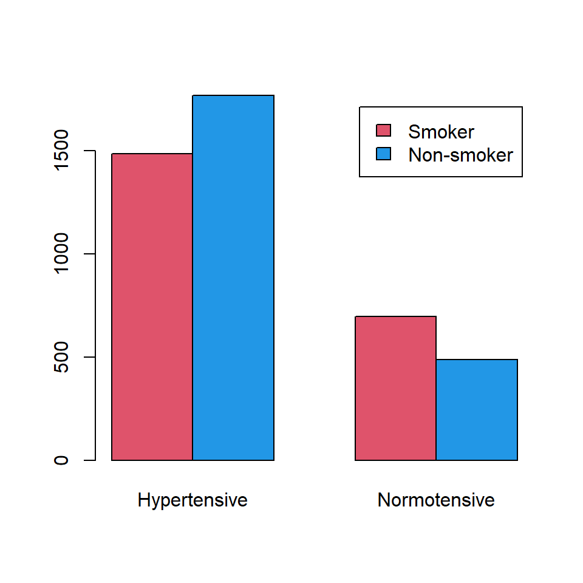

|  | Non-smoker (N=2253) | Smoker (N=2181) | Overall (N=4434) |
| --- | --- | --- | --- |
| HYPERTEN |  |  |  |
| Normotensive | 486 (21.6%) | 696 (31.9%) | 1182 (26.7%) |
| Hypertensive | 1767 (78.4%) | 1485 (68.1%) | 3252 (73.3%) |

The table suggests a pattern - to test and measure the effect we’ll use the RR, OR and RD, as reported in the output below.

```
##              Outcome +    Outcome -      Total        Inc risk *        Odds
## Exposed +         1485          696       2181              68.1        2.13
## Exposed -         1767          486       2253              78.4        3.64
## Total             3252         1182       4434              73.3        2.75
##
## Point estimates and 95% CIs:
## -------------------------------------------------------------------
## Inc risk ratio                               0.87 (0.84, 0.90)
## Odds ratio                                   0.59 (0.51, 0.67)
## Attrib risk *                                -10.34 (-12.93, -7.75)
## Attrib risk in population *                  -5.09 (-7.23, -2.95)
## Attrib fraction in exposed (%)               -15.19 (-19.41, -11.12)
## Attrib fraction in population (%)            -6.94 (-8.72, -5.18)
## -------------------------------------------------------------------
##  Test that OR = 1: chi2(1) = 60.610 Pr>chi2 = <0.001
##  Wald confidence limits
##  CI: confidence interval
##  * Outcomes per 100 population units
```

All three effects are significant, suggesting a protective effect of smoking on hypertension.

**OBJECTIVE 3** Report the effect measures (RR, OR, RD) with their CIs in an effective way.